# Reproducible Research, Course Project 1

Paulina Lopez

Friday, February 3, 2017

## Loading and preprocessing the data

1. Loading the data

```r
#Set working directory
setwd("C:\\Users\\J14168\\Documents\\Pau\\Data science coursera\\Reproducible Research\\")

#Load database
activity <- read.csv("activity.csv")
```

## What is mean total number of steps taken per day?

### 1. Calculate the total number of steps taken per day

```r
#Create database omitting missing values in "activity"
act2 <- na.omit(activity)
#Calculate total number of steps per day
total <- aggregate(act2$steps, by=list(act2$date), FUN=sum)
```

### 2. Make a histogram of the total number of steps taken each day

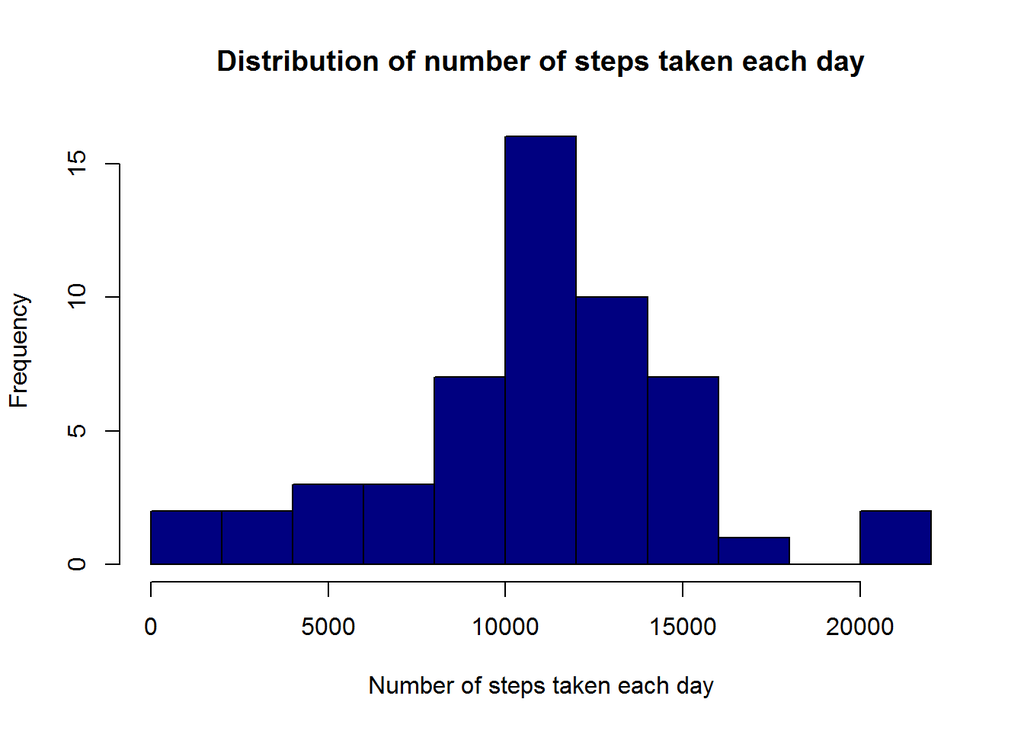

```r
hist(total$x, main="Distribution of number of steps taken each day", breaks=10, col="navyblue", xlab="Number of steps taken each day")
```

### 3. Calculate and report the mean and median of the total number of steps taken per day

# Mean

```r
mean(total$x)
```

```
## [1] 10766.19
```

# Median

```r
median(total$x)
```

```
## [1] 10765
```

## What is the average daily activity pattern?

### Calculate average number of steps by 5 minute interval

```r
meanstep <- aggregate(act2$steps, by=list(act2$interval), FUN=mean)
```

### 1. Make a time series plot (i.e. type = “l”) of the 5-minute interval (x-axis) and the average number of steps taken, averaged across all days (y-axis)

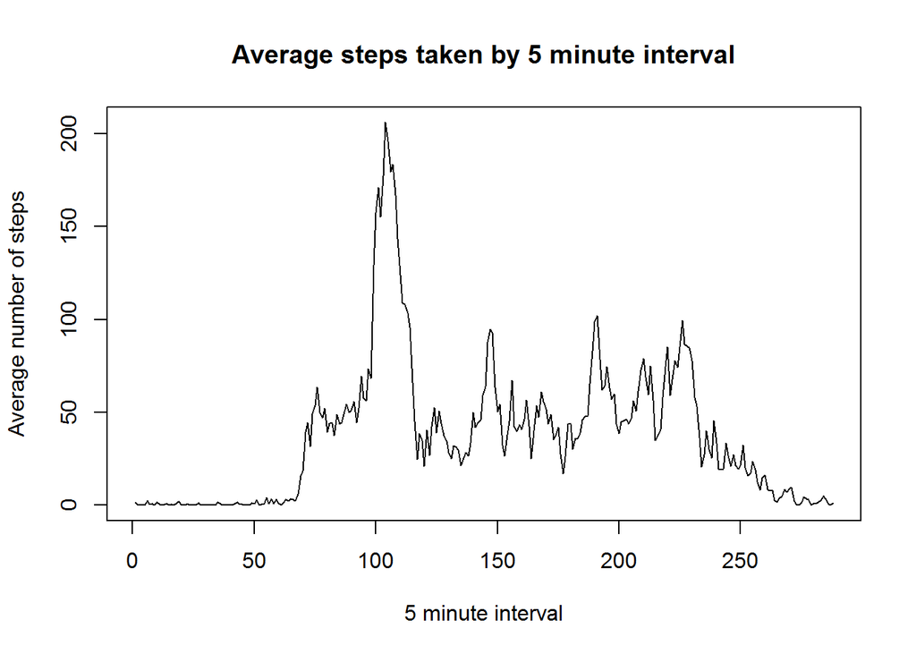

```r
plot(meanstep$x, type="l", main="Average steps taken by 5 minute interval", xlab="5 minute interval", ylab="Average number of steps")
```

### 2. Which 5-minute interval, on average across all the days in the dataset, contains the maximum number of steps?

```r
meanstep$Group.1[which.max(meanstep$x)]
```

```
## [1] 835
```

## Imputing missing values

### 1. Calculate and report the total number of missing values in the dataset (i.e. the total number of rows with NAs)

```r
sum(is.na(activity$steps))
```

```
## [1] 2304
```

```r
sum(is.na(activity$interval))
```

```
## [1] 0
```

```r
sum(is.na(activity$date))
```

```
## [1] 0
```

The only variable with missing values is steps, with a total of 2304 rows with missing values

### 2. Devise a strategy for filling in all of the missing values in the dataset. The strategy does not need to be sophisticated. For example, you could use the mean/median for that day, or the mean for that 5-minute interval, etc. 3. Create a new dataset that is equal to the original dataset but with the missing data filled in.

I will impute the median of each interval to the missing value for number of steps taken

```r
activity_wona <- activity

#Generate the medians for each 5 minute interval
medians <- aggregate(activity_wona$steps, by=list(activity_wona$interval), FUN=median, na.rm=TRUE)

#Merge with activity_wona database
activity_median <- merge(activity_wona,medians,by.x="interval",by.y="Group.1")


#Replace missing values
for (i in 1:nrow(activity_median)){
  if(is.na(activity_median$steps[i])){
    activity_median$steps[i]=activity_median$x[i]
  }
}
#Check that there are no more missings in steps column
sum(is.na(activity_median$steps))
```

```
## [1] 0
```

```r
#Erase the median by 5 minute interval column
activity_median$x=NULL
#Copy the new dataset as activity_wona
activity_wona<-activity_median
```

### 4. Make a histogram of the total number of steps taken each day and Calculate and report the mean and median total number of steps taken per day. Do these values differ from the estimates from the first part of the assignment? What is the impact of imputing missing data on the estimates of the total daily number of steps?

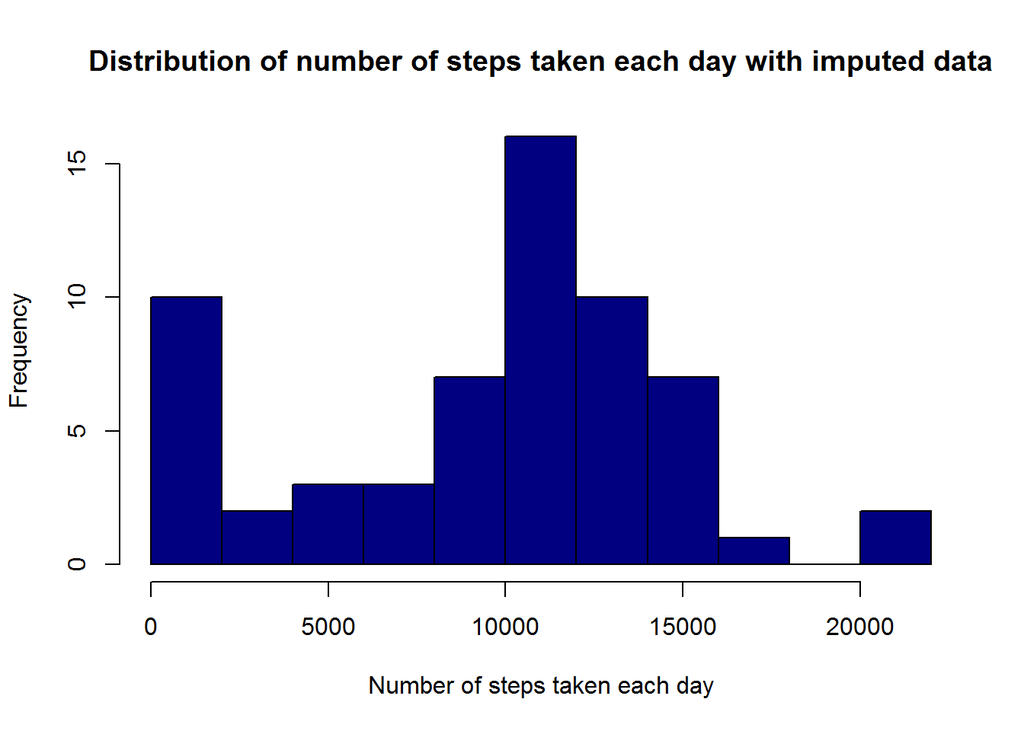

```r
#Calculate total number of steps per day
total_wona <- aggregate(activity_wona$steps, by=list(activity_wona$date), FUN=sum)

#Make histogram
hist(total_wona$x, main="Distribution of number of steps taken each day with imputed data", breaks=10, col="navyblue", xlab="Number of steps taken each day")
```

```r
#Calculate and report the mean of the total number of steps taken per day
mean(total_wona$x)
```

```
## [1] 9503.869
```

```r
#Calculate and report the median of the total number of steps taken per day
median(total_wona$x)
```

```
## [1] 10395
```

When the missing data is imputed, both the mean and the median of total steps taken each day is lower than when missing values are ignored. This is reasonable since, for many 5 minute intervals, the median of steps taken each day, which was the imputed value, is zero.

### Are there differences in activity patterns between weekdays and weekends?

### 1. Create a new factor variable in the dataset with two levels - “weekday” and “weekend” indicating whether a given date is a weekday or weekend day.

```r
#Generate weekday variable
activity_wona$day <- weekdays(as.Date(activity_wona$date))

#Generate factor variable for weekend and weekdays
activity_wona$weekend <- ifelse(activity_wona$day %in% c("sábado", "domingo"), "weekend", "weekday")
```

### 2. Make a panel plot containing a time series plot (i.e. type = “l”) of the 5-minute interval (x-axis) and the average number of steps taken, averaged across all weekday days or weekend days (y-axis). See the README file in the GitHub repository to see an example of what this plot should look like using simulated data.

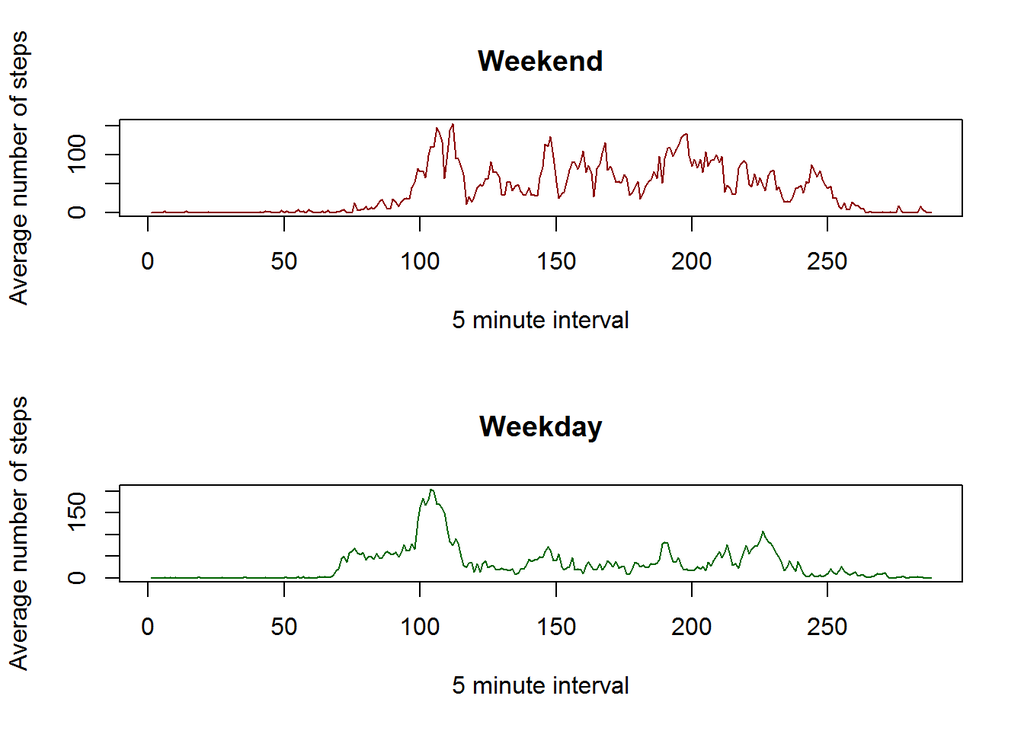

```r
#Generate database for weekend and weekday and calculate averages in both databases
weekend <- subset(activity_wona, activity_wona$weekend=="weekend")
weekday <- subset(activity_wona, activity_wona$weekend=="weekday")
mean_weekend <- aggregate(weekend$steps, by=list(weekend$interval), FUN=mean)
mean_weekday <- aggregate(weekday$steps, by=list(weekday$interval), FUN=mean)

par(mfrow=c(2,1))
plot(mean_weekend$x, type="l", main="Weekend", xlab="5 minute interval", ylab="Average number of steps", col="darkred")
plot(mean_weekday$x, type="l", main="Weekday", xlab="5 minute interval", ylab="Average number of steps", col="darkgreen")
```